# R Notebook

## Loess

```r
# Loess----
loess.AMZN <- loess.bias.var(AMZN_weekly$Close)
```

```r
loess.NFLX <- loess.bias.var(NFLX_weekly$Close)
```

```r
loess.ZOOM <- loess.bias.var(ZOOM_weekly$Close)
```

### AMZN

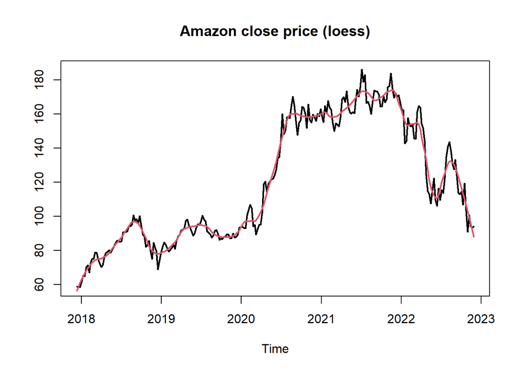

```r
### AMZN----
loess.AMZN.best <- loess(AMZN_weekly$Close~seq(1, length(AMZN_weekly$Close)),
                         span = loess.AMZN$Span[which(loess.AMZN$MSE ==
                                                        min(loess.AMZN$MSE))],
                         degree = 2)

plot(AMZN_weekly$Time, AMZN_weekly$Close,
     type = "l", lwd = 2, xlab = "Time", ylab = "",
     main = "Amazon close price (loess)")
j.AMZN <- order(AMZN_weekly$Time)
lines(AMZN_weekly$Time[j.AMZN],loess.AMZN.best$fitted[j.AMZN],
      col = 2, lwd = 2)
```

### NFLX

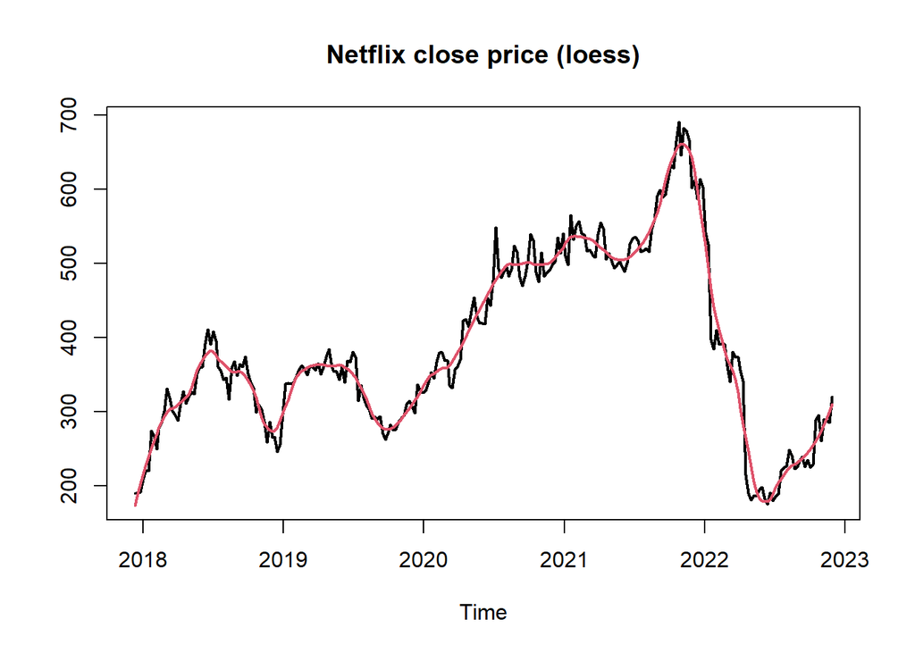

```r
### NFLX----
loess.NFLX.best <- loess(NFLX_weekly$Close~seq(1, length(NFLX_weekly$Close)),
                         span = loess.NFLX$Span[which(loess.NFLX$MSE ==
                                                        min(loess.NFLX$MSE))],
                         degree = 2)

plot(NFLX_weekly$Time, NFLX_weekly$Close,
     type = "l", lwd = 2, xlab = "Time", ylab = "",
     main = "Netflix close price (loess)")
j.NFLX <- order(NFLX_weekly$Time)
lines(NFLX_weekly$Time[j.NFLX],
      loess.NFLX.best$fitted[j.NFLX], col = 2, lwd = 2)
```

### ZOOM

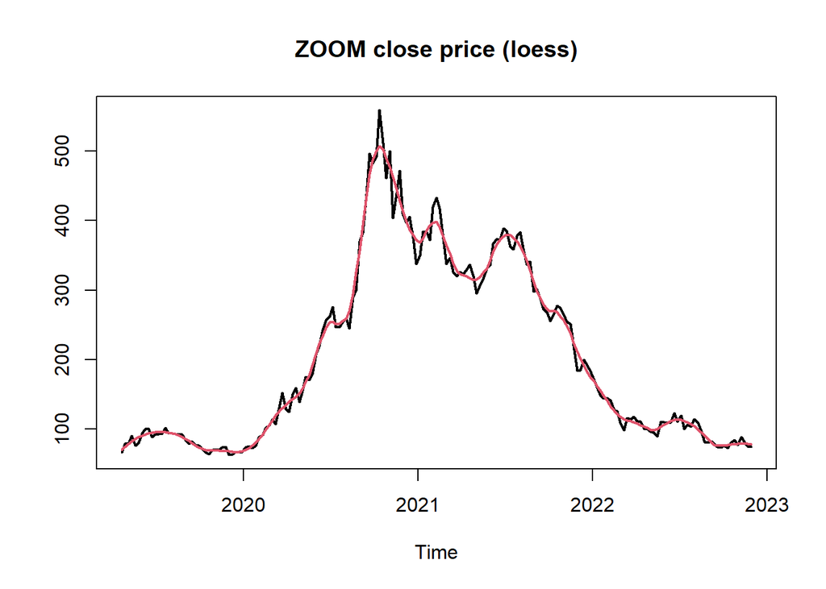

```r
### ZOOM----
loess.ZOOM.best <- loess(ZOOM_weekly$Close~seq(1, length(ZOOM_weekly$Close)),
                         span = seq(0.1, 3,
                                    length.out = 300)
                         [which(loess.ZOOM$MSE ==
                                  min(loess.ZOOM$MSE))],
                         degree = 2)

plot(ZOOM_weekly$Time, ZOOM_weekly$Close, type = "l",
     lwd = 2, xlab = "Time", ylab = "",
     main = "ZOOM close price (loess)")
j.ZOOM <- order(ZOOM_weekly$Time)
lines(ZOOM_weekly$Time[j.ZOOM],
      loess.ZOOM.best$fitted[j.ZOOM], col = 2, lwd = 2)
```

## Local Regression

```r
# Local Regression----
locreg.AMZN <- locreg.bias.var(AMZN_weekly)
```

```r
locreg.NFLX <- locreg.bias.var(NFLX_weekly)
```

```r
locreg.ZOOM <- locreg.bias.var(ZOOM_weekly)
```

```r
best.h.AMZN <- locreg.AMZN$h.param[which(locreg.AMZN$MSE
                                         == min(locreg.AMZN$MSE))]
best.h.NFLX <- locreg.NFLX$h.param[which(locreg.NFLX$MSE
                                         == min(locreg.NFLX$MSE))]
best.h.ZOOM <- locreg.ZOOM$h.param[which(locreg.ZOOM$MSE
                                         == min(locreg.ZOOM$MSE))]
```

### AMZN

#### Pandemic related events exhibited

- Start of the pandemic (beginning of 2020)
- Price of the actions is not too much influenced by all the subsequent waves (second - beginning of 2021, third - end of April 2021, fourth - August 2021) since the price kept fairly high throughout all that period.
- Closely following the days of fifth wave (beginning of maximum daily cases), there is another increase.

#### Financial related events exhibited

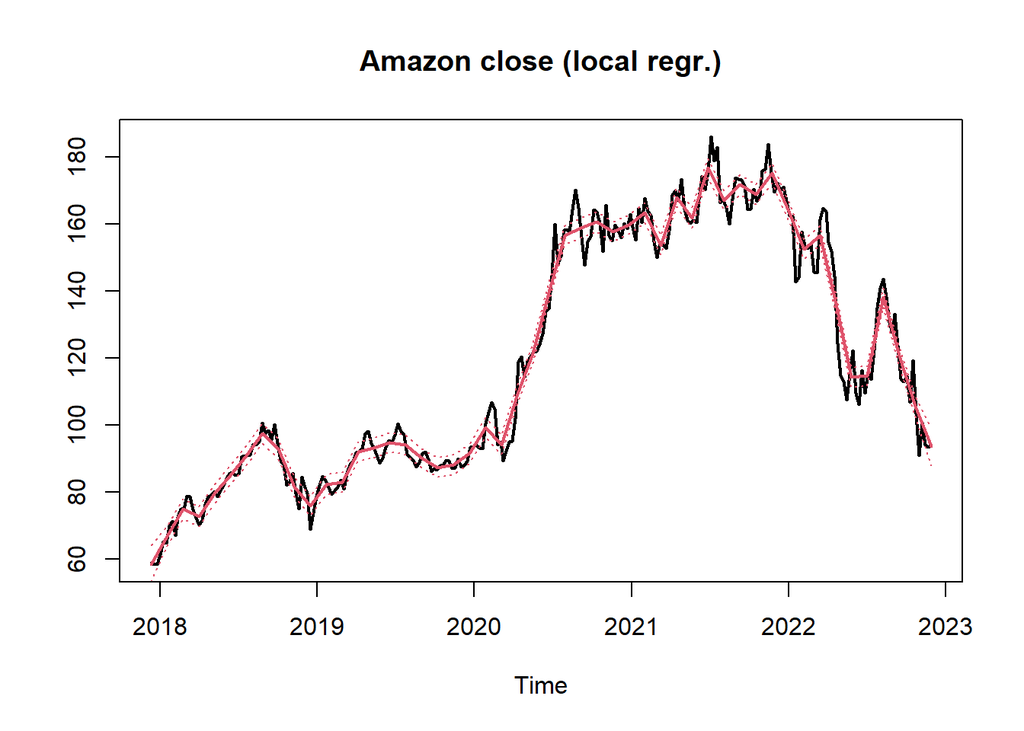

```r
### AMZN----
plot(AMZN_weekly$Time, AMZN_weekly$Close,
     xlab = "Time", main = "Amazon close (local regr.)",
     ylab = "", lwd = 2, type = "l")
sm.regression(AMZN_weekly$Time, AMZN_weekly$Close, h = best.h.AMZN,
              add = T, col = 2,  display = "se", lwd = 2)
```

### NFLX

#### Financial related events exhibited

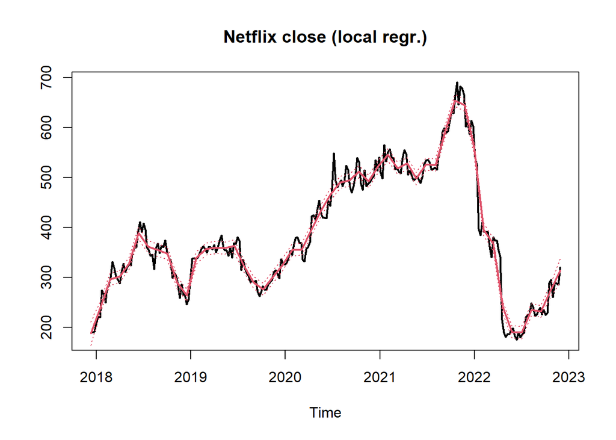

```r
### NFLX----
plot(NFLX_weekly$Time, NFLX_weekly$Close,
     xlab = "Time", main = "Netflix close (local regr.)",
     ylab = "", lwd = 2, type = "l")
sm.regression(NFLX_weekly$Time, NFLX_weekly$Close, h = best.h.NFLX,
              add = T, col = 2,  display = "se", lwd = 2)
```

### ZOOM

#### Financial related events exhibited

The **fiscal year** of ZOOM starts on February, 1st and ends on January, 31st of the following year.

- In Q1 (February-April) 2020, there is the launuch of Zoom Phone. This may have accelerated the growth in that period.
- Major event of 2020, is partnership with Verizon (Q2 2020)
- Q1 2021 is the first quarter in which COVID is mentioned in the report to shareholders.
- The peak in the Q2 2021 may be associated with the launch of two new products (Zoom for Home and Zoom Hardware as a Service).
- Q1 2022 sees also the launch of the app ecosystem (Zoom Apps).

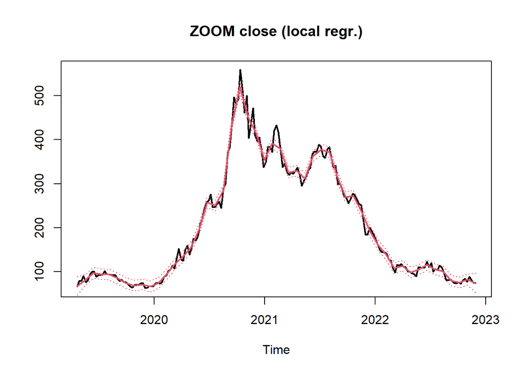

```r
### ZOOM----
plot(ZOOM_weekly$Time, ZOOM_weekly$Close,
     xlab = "Time", main = "ZOOM close (local regr.)",
     ylab = "", lwd = 2, type = "l")
sm.regression(ZOOM_weekly$Time, ZOOM_weekly$Close, h = best.h.ZOOM,
              add = T, col = 2,  display = "se", lwd = 2)
```

## Splines

```r
# Splines----
sspline.AMZN <- sspline.bias.var(AMZN_weekly)
```

```r
sspline.NFLX <- sspline.bias.var(NFLX_weekly)
```

```r
sspline.ZOOM <- sspline.bias.var(ZOOM_weekly)
```

```r
best.lambda.AMZN <- sspline.AMZN$lambda[which(sspline.AMZN$MSE
                                              == min(sspline.AMZN$MSE))]
best.lambda.NFLX <- sspline.NFLX$lambda[which(sspline.NFLX$MSE
                                              == min(sspline.NFLX$MSE))]
best.lambda.ZOOM <- sspline.ZOOM$lambda[which(sspline.ZOOM$MSE
                                              == min(sspline.ZOOM$MSE))]
```

### AMZN

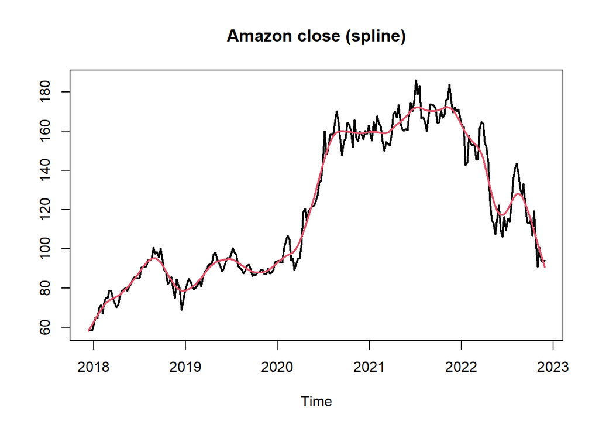

```r
### AMZN----
plot(AMZN_weekly$Time, AMZN_weekly$Close,
     xlab = "Time", main = "Amazon close (spline)",
     ylab = "", type = "l", lwd = 2)
lines(smooth.spline(AMZN_weekly$Time, AMZN_weekly$Close,
                    lambda = best.lambda.AMZN),
      col = 2, lwd = 2)
```

### NFLX

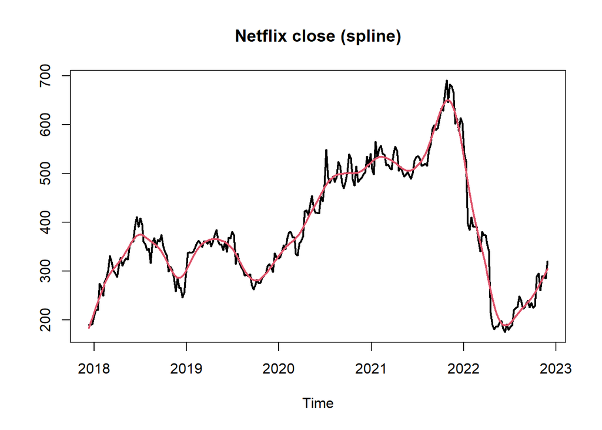

```r
### NFLX----
plot(NFLX_weekly$Time, NFLX_weekly$Close,
     xlab = "Time", main = "Netflix close (spline)",
     ylab = "", type = "l", lwd = 2)
lines(smooth.spline(NFLX_weekly$Time, NFLX_weekly$Close,
                    lambda = best.lambda.NFLX),
      col = 2, lwd = 2)
```

### ZOOM

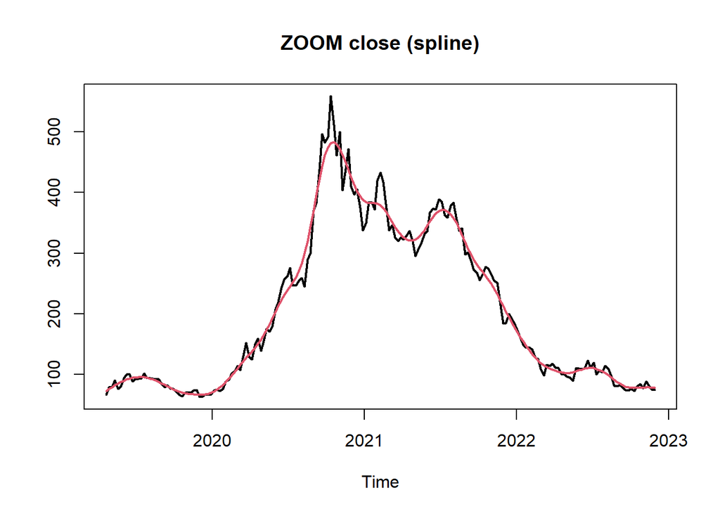

```r
### ZOOM----
plot(ZOOM_weekly$Time, ZOOM_weekly$Close,
     xlab = "Time", main = "ZOOM close (spline)",
     ylab = "", type = "l", lwd = 2)
lines(smooth.spline(ZOOM_weekly$Time, ZOOM_weekly$Close,
                    lambda = best.lambda.ZOOM),
      col = 2, lwd = 2)
```

```r
# BEST MODELS ----

### AMZN----
setNames(c(min(loess.AMZN$MSE), min(locreg.AMZN$MSE),
           min(sspline.AMZN$MSE)),
         c("Loess", "Loc. Regr.", "Spline"))
```

```
##      Loess Loc. Regr.     Spline
##   24.31378   22.33191   30.11062
```

```r
best.h.AMZN
```

```
## [1] 10
```

```r
# best model for AMZN: local regression, with h = 10


### NFLX----
setNames(c(min(loess.NFLX$MSE), min(locreg.NFLX$MSE),
           min(sspline.NFLX$MSE)),
         c("Loess", "Loc. Regr.", "Spline"))
```

```
##      Loess Loc. Regr.     Spline
##   380.1758   361.0895   461.5902
```

```r
best.h.NFLX
```

```
## [1] 10
```

```r
# best model for NFLX: local regression, with h = 10

### ZOOM----
setNames(c(min(loess.ZOOM$MSE), min(locreg.ZOOM$MSE),
           min(sspline.ZOOM$MSE)),
         c("Loess", "Loc. Regr.", "Spline"))
```

```
##      Loess Loc. Regr.     Spline
##   146.8186   143.9809   267.9024
```

```r
best.h.ZOOM
```

```
## [1] 7
```

```r
# best model for ZOOM: local regression, with h = 7
```